# Survey Dashboard

### **Q9.8.12 Draft a new permanent constitution**

#### Entire sample

| mean |
| --- |
| NA |

[output not shown]

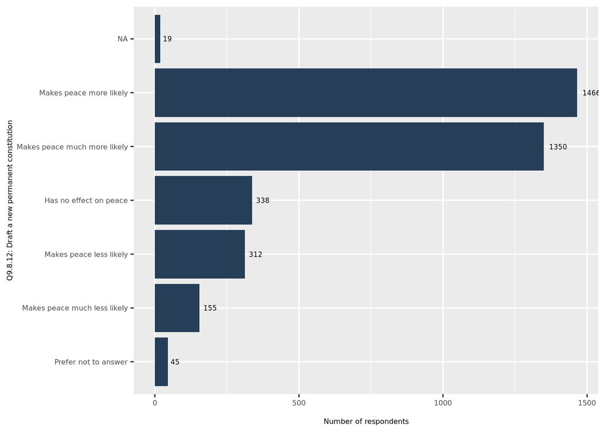

#### By county

[output not shown]

| County | Response | Number of Responses | Percent of Total Responses |
| --- | --- | --- | --- |
| Yei | Has no effect on peace | 35 | 0.09 |
| Yei | Makes peace less likely | 26 | 0.06 |
| Yei | Makes peace more likely | 206 | 0.50 |
| Yei | Makes peace much less likely | 6 | 0.01 |
| Yei | Makes peace much more likely | 132 | 0.32 |
| Yei | Prefer not to answer | 1 | 0.00 |
| Yei | NA | 4 | 0.01 |
| Wau | Has no effect on peace | 19 | 0.05 |
| Wau | Makes peace less likely | 22 | 0.05 |
| Wau | Makes peace more likely | 157 | 0.39 |
| Wau | Makes peace much less likely | 35 | 0.09 |
| Wau | Makes peace much more likely | 139 | 0.35 |
| Wau | Prefer not to answer | 25 | 0.06 |
| Wau | NA | 5 | 0.01 |
| Rubkona | Has no effect on peace | 10 | 0.03 |
| Rubkona | Makes peace less likely | 40 | 0.10 |
| Rubkona | Makes peace more likely | 74 | 0.18 |
| Rubkona | Makes peace much less likely | 28 | 0.07 |
| Rubkona | Makes peace much more likely | 247 | 0.62 |
| Rubkona | Prefer not to answer | 1 | 0.00 |
| Pibor | Has no effect on peace | 60 | 0.15 |
| Pibor | Makes peace less likely | 37 | 0.09 |
| Pibor | Makes peace more likely | 176 | 0.43 |
| Pibor | Makes peace much less likely | 24 | 0.06 |
| Pibor | Makes peace much more likely | 106 | 0.26 |
| Pibor | Prefer not to answer | 1 | 0.00 |
| Pibor | NA | 3 | 0.01 |
| Morobo | Has no effect on peace | 67 | 0.17 |
| Morobo | Makes peace less likely | 51 | 0.13 |
| Morobo | Makes peace more likely | 115 | 0.28 |
| Morobo | Makes peace much less likely | 20 | 0.05 |
| Morobo | Makes peace much more likely | 149 | 0.37 |
| Morobo | NA | 2 | 0.00 |
| Malakal | Has no effect on peace | 45 | 0.11 |
| Malakal | Makes peace less likely | 19 | 0.05 |
| Malakal | Makes peace more likely | 280 | 0.67 |
| Malakal | Makes peace much more likely | 75 | 0.18 |
| Malakal | NA | 2 | 0.00 |
| Lainya | Has no effect on peace | 62 | 0.15 |
| Lainya | Makes peace less likely | 42 | 0.10 |
| Lainya | Makes peace more likely | 169 | 0.41 |
| Lainya | Makes peace much less likely | 20 | 0.05 |
| Lainya | Makes peace much more likely | 116 | 0.28 |
| Lainya | Prefer not to answer | 4 | 0.01 |
| Lainya | NA | 1 | 0.00 |
| Kajo-keji | Has no effect on peace | 33 | 0.08 |
| Kajo-keji | Makes peace less likely | 45 | 0.11 |
| Kajo-keji | Makes peace more likely | 117 | 0.29 |
| Kajo-keji | Makes peace much less likely | 7 | 0.02 |
| Kajo-keji | Makes peace much more likely | 183 | 0.46 |
| Kajo-keji | Prefer not to answer | 12 | 0.03 |
| Kajo-keji | NA | 1 | 0.00 |
| Bor South | Has no effect on peace | 7 | 0.02 |
| Bor South | Makes peace less likely | 30 | 0.07 |
| Bor South | Makes peace more likely | 172 | 0.40 |
| Bor South | Makes peace much less likely | 15 | 0.03 |
| Bor South | Makes peace much more likely | 203 | 0.47 |
| Bor South | Prefer not to answer | 1 | 0.00 |
| Bor South | NA | 1 | 0.00 |

**Q9.9 Which actors should be involved in efforts to bring peace to the communities? (Do not read the answers; mark all that apply) - BAD WILL DEBUG LATER**

1. Community members
2. Religious leaders
3. Government authorities (at county, payam level)
4. Army
5. Community leaders
6. NGOs / UN
7. Others: _______

-2. Prefer not to answer

#### Entire sample

| mean |
| --- |
| NA |

0.11

150

0.04

6. NGOs / UN

131

0.04

2. Religious leaders

110

0.03

1. Community members

107

0.03

1. Community members 2. Religious leaders 5. Community leaders

89

0.02

3. Government authorities (at county, payam level)

73

0.02

1. Community members 2. Religious leaders 3. Government authorities (at county, payam level) 5. Community leaders

68

0.02

1. Community members 2. Religious leaders 4. Army 5. Community leaders

49

0.01

1. Community members 2. Religious leaders 3. Government authorities (at county, payam level) 4. Army 5. Community leaders

43

0.01

6. NGOs / UN 5. Community leaders 4. Army 3. Government authorities (at county, payam level) 2. Religious leaders 1. Community members

43

0.01

5. Community leaders

33

0.01

1. Community members 2. Religious leaders 3. Government authorities (at county, payam level)

30

0.01

2. Religious leaders 3. Government authorities (at county, payam level) 4. Army 5. Community leaders 6. NGOs / UN

29

0.01

2. Religious leaders 3. Government authorities (at county, payam level) 6. NGOs / UN

29

0.01

2. Religious leaders 1. Community members 3. Government authorities (at county, payam level) 4. Army 5. Community leaders 6. NGOs / UN

27

0.01

2. Religious leaders 6. NGOs / UN

27

0.01

1. Community members 2. Religious leaders 5. Community leaders 6. NGOs / UN

26

0.01

1. Community members 3. Government authorities (at county, payam level) 5. Community leaders

26

0.01

1. Community members 2. Religious leaders

25

0.01

1. Community members 2. Religious leaders 3. Government authorities (at county, payam level) 4. Army 6. NGOs / UN 5. Community leaders

25

0.01

1. Community members 5. Community leaders

25

0.01

2. Religious leaders 5. Community leaders 6. NGOs / UN

25

0.01

2. Religious leaders 1. Community members 5. Community leaders

24

0.01

2. Religious leaders 5. Community leaders

22

0.01

1. Community members 2. Religious leaders 3. Government authorities (at county, payam level) 6. NGOs / UN 5. Community leaders

21

0.01

2. Religious leaders 1. Community members

21

0.01

2. Religious leaders 3. Government authorities (at county, payam level) 4. Army 5. Community leaders

21

0.01

1. Community members 2. Religious leaders 3. Government authorities (at county, payam level) 4. Army 6. NGOs / UN

20

0.01

1. Community members 2. Religious leaders 4. Army 5. Community leaders 6. NGOs / UN

20

0.01

1. Community members 2. Religious leaders 5. Community leaders 3. Government authorities (at county, payam level)

20

0.01

2. Religious leaders 3. Government authorities (at county, payam level) 5. Community leaders

20

0.01

6. NGOs / UN 3. Government authorities (at county, payam level)

20

0.01

6. NGOs / UN 5. Community leaders 3. Government authorities (at county, payam level)

20

0.01

1. Community members 5. Community leaders 6. NGOs / UN

19

0.01

2. Religious leaders 3. Government authorities (at county, payam level)

19

0.01

1. Community members 2. Religious leaders 3. Government authorities (at county, payam level) 5. Community leaders 4. Army 6. NGOs / UN

18

0.00

1. Community members 2. Religious leaders 6. NGOs / UN 5. Community leaders

18

0.00

1. Community members 3. Government authorities (at county, payam level) 6. NGOs / UN

18

0.00

1. Community members 2. Religious leaders 4. Army

17

0.00

2. Religious leaders 3. Government authorities (at county, payam level) 5. Community leaders 6. NGOs / UN

17

0.00

1. Community members 2. Religious leaders 4. Army 6. NGOs / UN

16

0.00

3. Government authorities (at county, payam level) 6. NGOs / UN

16

0.00

6. NGOs / UN 2. Religious leaders

16

0.00

1. Community members 2. Religious leaders 3. Government authorities (at county, payam level) 5. Community leaders 6. NGOs / UN 4. Army

14

0.00

1. Community members 2. Religious leaders 6. NGOs / UN

14

0.00

2. Religious leaders 1. Community members 6. NGOs / UN

14

0.00

3. Government authorities (at county, payam level) 2. Religious leaders 1. Community members 4. Army 5. Community leaders 6. NGOs / UN

14

0.00

6. NGOs / UN 2. Religious leaders 3. Government authorities (at county, payam level)

14

0.00

6. NGOs / UN 5. Community leaders 3. Government authorities (at county, payam level) 2. Religious leaders 1. Community members

14

0.00

1. Community members 6. NGOs / UN

13

0.00

6. NGOs / UN 3. Government authorities (at county, payam level) 1. Community members

13

0.00

1. Community members 2. Religious leaders 3. Government authorities (at county, payam level) 4. Army 5. Community leaders 6. NGOs / UN 7. Others: _______

12

0.00

1. Community members 2. Religious leaders 3. Government authorities (at county, payam level) 6. NGOs / UN

12

0.00

1. Community members 3. Government authorities (at county, payam level) 5. Community leaders 6. NGOs / UN

12

0.00

2. Religious leaders 6. NGOs / UN 5. Community leaders

12

0.00

3. Government authorities (at county, payam level) 4. Army

12

0.00

5. Community leaders 2. Religious leaders 1. Community members

12

0.00

1. Community members 3. Government authorities (at county, payam level)

11

0.00

2. Religious leaders 1. Community members 3. Government authorities (at county, payam level) 5. Community leaders 6. NGOs / UN

11

0.00

2. Religious leaders 3. Government authorities (at county, payam level) 4. Army 5. Community leaders 6. NGOs / UN 1. Community members

11

0.00

3. Government authorities (at county, payam level) 2. Religious leaders

11

0.00

1. Community members 2. Religious leaders 3. Government authorities (at county, payam level) 4. Army

10

0.00

5. Community leaders 1. Community members

10

0.00

1. Community members 3. Government authorities (at county, payam level) 4. Army 5. Community leaders

9

0.00

1. Community members 6. NGOs / UN 5. Community leaders

9

0.00

2. Religious leaders 1. Community members 3. Government authorities (at county, payam level) 5. Community leaders

9

0.00

2. Religious leaders 1. Community members 5. Community leaders 6. NGOs / UN

9

0.00

2. Religious leaders 3. Government authorities (at county, payam level) 4. Army

9

0.00

3. Government authorities (at county, payam level) 4. Army 5. Community leaders

9

0.00

3. Government authorities (at county, payam level) 4. Army 6. NGOs / UN

9

0.00

3. Government authorities (at county, payam level) 5. Community leaders 6. NGOs / UN

9

0.00

3. Government authorities (at county, payam level) 6. NGOs / UN 2. Religious leaders

9

0.00

6. NGOs / UN 3. Government authorities (at county, payam level) 2. Religious leaders

9

0.00

1. Community members 2. Religious leaders 4. Army 5. Community leaders 6. NGOs / UN 3. Government authorities (at county, payam level)

8

0.00

1. Community members 2. Religious leaders 5. Community leaders 6. NGOs / UN 3. Government authorities (at county, payam level)

8

0.00

2. Religious leaders 1. Community members 3. Government authorities (at county, payam level)

8

0.00

2. Religious leaders 3. Government authorities (at county, payam level) 1. Community members 5. Community leaders 6. NGOs / UN

8

0.00

2. Religious leaders 3. Government authorities (at county, payam level) 4. Army 6. NGOs / UN

8

0.00

2. Religious leaders 3. Government authorities (at county, payam level) 6. NGOs / UN 5. Community leaders

8

0.00

2. Religious leaders 5. Community leaders 1. Community members

8

0.00

2. Religious leaders 6. NGOs / UN 3. Government authorities (at county, payam level)

8

0.00

3. Government authorities (at county, payam level) 1. Community members 2. Religious leaders 4. Army 5. Community leaders 6. NGOs / UN

8

0.00

3. Government authorities (at county, payam level) 2. Religious leaders 6. NGOs / UN

8

0.00

4. Army 5. Community leaders 6. NGOs / UN 3. Government authorities (at county, payam level) 2. Religious leaders 1. Community members

8

0.00

5. Community leaders 3. Government authorities (at county, payam level)

8

0.00

6. NGOs / UN 1. Community members

8

0.00

6. NGOs / UN 1. Community members 2. Religious leaders 3. Government authorities (at county, payam level)

8

0.00

1. Community members 2. Religious leaders 4. Army 3. Government authorities (at county, payam level) 5. Community leaders 6. NGOs / UN

7

0.00

1. Community members 3. Government authorities (at county, payam level) 6. NGOs / UN 5. Community leaders

7

0.00

1. Community members 4. Army 5. Community leaders 6. NGOs / UN

7

0.00

2. Religious leaders 1. Community members 3. Government authorities (at county, payam level) 4. Army 5. Community leaders

7

0.00

2. Religious leaders 5. Community leaders 6. NGOs / UN 3. Government authorities (at county, payam level)

7

0.00

3. Government authorities (at county, payam level) 2. Religious leaders 1. Community members

7

0.00

5. Community leaders 2. Religious leaders

7

0.00

6. NGOs / UN 1. Community members 2. Religious leaders 5. Community leaders

7

0.00

1. Community members 2. Religious leaders 5. Community leaders 4. Army 3. Government authorities (at county, payam level) 6. NGOs / UN

6

0.00

1. Community members 2. Religious leaders 6. NGOs / UN 3. Government authorities (at county, payam level)

6

0.00

1. Community members 3. Government authorities (at county, payam level) 4. Army 5. Community leaders 6. NGOs / UN

6

0.00

1. Community members 5. Community leaders 3. Government authorities (at county, payam level)

6

0.00

1. Community members 5. Community leaders 6. NGOs / UN 3. Government authorities (at county, payam level)

6

0.00

2. Religious leaders 1. Community members 4. Army 5. Community leaders

6

0.00

2. Religious leaders 5. Community leaders 6. NGOs / UN 1. Community members

6

0.00

2. Religious leaders 6. NGOs / UN 1. Community members

6

0.00

2. Religious leaders 6. NGOs / UN 4. Army

6

0.00

3. Government authorities (at county, payam level) 1. Community members 6. NGOs / UN 5. Community leaders

6

0.00

3. Government authorities (at county, payam level) 4. Army 5. Community leaders 6. NGOs / UN

6

0.00

4. Army 3. Government authorities (at county, payam level)

6

0.00

5. Community leaders 1. Community members 2. Religious leaders

6

0.00

5. Community leaders 3. Government authorities (at county, payam level) 2. Religious leaders

6

0.00

5. Community leaders 3. Government authorities (at county, payam level) 2. Religious leaders 1. Community members

6

0.00

5. Community leaders 3. Government authorities (at county, payam level) 6. NGOs / UN

6

0.00

5. Community leaders 6. NGOs / UN

6

0.00

6. NGOs / UN 1. Community members 5. Community leaders

6

0.00

6. NGOs / UN 5. Community leaders

6

0.00

6. NGOs / UN 5. Community leaders 2. Religious leaders

6

0.00

6. NGOs / UN 5. Community leaders 4. Army 2. Religious leaders 1. Community members 3. Government authorities (at county, payam level)

6

0.00

7. Others: _______

6

0.00

_2. Prefer not to answer

6

0.00

1. Community members 2. Religious leaders 3. Government authorities (at county, payam level) 5. Community leaders 4. Army

5

0.00

1. Community members 2. Religious leaders 4. Army 3. Government authorities (at county, payam level) 5. Community leaders

5

0.00

1. Community members 2. Religious leaders 4. Army 6. NGOs / UN 5. Community leaders

5

0.00

1. Community members 2. Religious leaders 6. NGOs / UN 4. Army

5

0.00

1. Community members 3. Government authorities (at county, payam level) 5. Community leaders 4. Army

5

0.00

1. Community members 5. Community leaders 2. Religious leaders

5

0.00

2. Religious leaders 1. Community members 4. Army 5. Community leaders 6. NGOs / UN

5

0.00

2. Religious leaders 3. Government authorities (at county, payam level) 1. Community members 4. Army 5. Community leaders 6. NGOs / UN

5

0.00

2. Religious leaders 3. Government authorities (at county, payam level) 4. Army 5. Community leaders 1. Community members 6. NGOs / UN

5

0.00

2. Religious leaders 4. Army 5. Community leaders

5

0.00

3. Government authorities (at county, payam level) 1. Community members 2. Religious leaders 5. Community leaders 6. NGOs / UN

5

0.00

3. Government authorities (at county, payam level) 2. Religious leaders 4. Army

5

0.00

3. Government authorities (at county, payam level) 4. Army 2. Religious leaders

5

0.00

3. Government authorities (at county, payam level) 5. Community leaders 1. Community members

5

0.00

4. Army 3. Government authorities (at county, payam level) 2. Religious leaders 1. Community members 5. Community leaders 6. NGOs / UN

5

0.00

4. Army 3. Government authorities (at county, payam level) 2. Religious leaders 1. Community members 6. NGOs / UN 5. Community leaders

5

0.00

4. Army 6. NGOs / UN 3. Government authorities (at county, payam level) 2. Religious leaders

5

0.00

5. Community leaders 4. Army 2. Religious leaders 1. Community members

5

0.00

5. Community leaders 6. NGOs / UN 4. Army 3. Government authorities (at county, payam level) 2. Religious leaders 1. Community members

5

0.00

6. NGOs / UN 1. Community members 2. Religious leaders

5

0.00

6. NGOs / UN 2. Religious leaders 1. Community members

5

0.00

6. NGOs / UN 2. Religious leaders 1. Community members 5. Community leaders

5

0.00

6. NGOs / UN 2. Religious leaders 5. Community leaders 1. Community members

5

0.00

6. NGOs / UN 4. Army 2. Religious leaders 3. Government authorities (at county, payam level)

5

0.00

6. NGOs / UN 5. Community leaders 1. Community members

5

0.00

6. NGOs / UN 5. Community leaders 3. Government authorities (at county, payam level) 1. Community members

5

0.00

6. NGOs / UN 5. Community leaders 4. Army 3. Government authorities (at county, payam level)

5

0.00

6. NGOs / UN 5. Community leaders 4. Army 3. Government authorities (at county, payam level) 2. Religious leaders

5

0.00

1. Community members 2. Religious leaders 3. Government authorities (at county, payam level) 5. Community leaders 6. NGOs / UN 7. Others: _______

4

0.00

1. Community members 2. Religious leaders 5. Community leaders 4. Army

4

0.00

1. Community members 2. Religious leaders 6. NGOs / UN 5. Community leaders 3. Government authorities (at county, payam level)

4

0.00

1. Community members 3. Government authorities (at county, payam level) 2. Religious leaders 4. Army 5. Community leaders 6. NGOs / UN

4

0.00

1. Community members 3. Government authorities (at county, payam level) 2. Religious leaders 5. Community leaders 6. NGOs / UN

4

0.00

1. Community members 3. Government authorities (at county, payam level) 4. Army 5. Community leaders 6. NGOs / UN 2. Religious leaders

4

0.00

1. Community members 3. Government authorities (at county, payam level) 4. Army 6. NGOs / UN

4

0.00

1. Community members 4. Army 2. Religious leaders 5. Community leaders

4

0.00

1. Community members 4. Army 6. NGOs / UN

4

0.00

1. Community members 5. Community leaders 7. Others: _______

4

0.00

1. Community members 6. NGOs / UN 3. Government authorities (at county, payam level)

4

0.00

1. Community members 6. NGOs / UN 3. Government authorities (at county, payam level) 2. Religious leaders

4

0.00

2. Religious leaders 1. Community members 4. Army 6. NGOs / UN

4

0.00

2. Religious leaders 3. Government authorities (at county, payam level) 1. Community members

4

0.00

2. Religious leaders 3. Government authorities (at county, payam level) 4. Army 5. Community leaders 1. Community members

4

0.00

2. Religious leaders 4. Army

4

0.00

2. Religious leaders 4. Army 6. NGOs / UN 5. Community leaders

4

0.00

2. Religious leaders 5. Community leaders 3. Government authorities (at county, payam level)

4

0.00

3. Government authorities (at county, payam level) 1. Community members 2. Religious leaders 6. NGOs / UN

4

0.00

3. Government authorities (at county, payam level) 1. Community members 5. Community leaders

4

0.00

3. Government authorities (at county, payam level) 1. Community members 5. Community leaders 6. NGOs / UN

4

0.00

3. Government authorities (at county, payam level) 2. Religious leaders 5. Community leaders 6. NGOs / UN

4

0.00

3. Government authorities (at county, payam level) 4. Army 6. NGOs / UN 1. Community members

4

0.00

3. Government authorities (at county, payam level) 5. Community leaders 2. Religious leaders

4

0.00

3. Government authorities (at county, payam level) 5. Community leaders 6. NGOs / UN 2. Religious leaders

4

0.00

3. Government authorities (at county, payam level) 6. NGOs / UN 5. Community leaders

4

0.00

4. Army

4

0.00

4. Army 1. Community members 2. Religious leaders 3. Government authorities (at county, payam level) 5. Community leaders 6. NGOs / UN

4

0.00

4. Army 1. Community members 2. Religious leaders 5. Community leaders

4

0.00

4. Army 3. Government authorities (at county, payam level) 2. Religious leaders

4

0.00

4. Army 5. Community leaders 3. Government authorities (at county, payam level) 2. Religious leaders 1. Community members 6. NGOs / UN

4

0.00

4. Army 6. NGOs / UN

4

0.00

5. Community leaders 1. Community members 3. Government authorities (at county, payam level)

4

0.00

6. NGOs / UN 2. Religious leaders 5. Community leaders

4

0.00

6. NGOs / UN 3. Government authorities (at county, payam level) 2. Religious leaders 1. Community members

4

0.00

6. NGOs / UN 3. Government authorities (at county, payam level) 5. Community leaders

4

0.00

6. NGOs / UN 4. Army

4

0.00

6. NGOs / UN 5. Community leaders 2. Religious leaders 1. Community members

4

0.00

6. NGOs / UN 5. Community leaders 4. Army 2. Religious leaders

4

0.00

6. NGOs / UN 5. Community leaders 4. Army 2. Religious leaders 1. Community members

4

0.00

1. Community members 2. Religious leaders 3. Government authorities (at county, payam level) 6. NGOs / UN 4. Army 5. Community leaders

3

0.00

1. Community members 2. Religious leaders 3. Government authorities (at county, payam level) 6. NGOs / UN 5. Community leaders 4. Army

3

0.00

1. Community members 2. Religious leaders 4. Army 3. Government authorities (at county, payam level) 6. NGOs / UN 5. Community leaders

3

0.00

1. Community members 2. Religious leaders 4. Army 5. Community leaders 3. Government authorities (at county, payam level)

3

0.00

1. Community members 2. Religious leaders 5. Community leaders 6. NGOs / UN 3. Government authorities (at county, payam level) 4. Army

3

0.00

1. Community members 2. Religious leaders 6. NGOs / UN 3. Government authorities (at county, payam level) 5. Community leaders

3

0.00

1. Community members 3. Government authorities (at county, payam level) 2. Religious leaders 5. Community leaders

3

0.00

1. Community members 3. Government authorities (at county, payam level) 4. Army 2. Religious leaders 5. Community leaders 6. NGOs / UN

3

0.00

1. Community members 3. Government authorities (at county, payam level) 4. Army 6. NGOs / UN 5. Community leaders

3

0.00

1. Community members 3. Government authorities (at county, payam level) 6. NGOs / UN 4. Army

3

0.00

1. Community members 4. Army 3. Government authorities (at county, payam level) 5. Community leaders

3

0.00

1. Community members 4. Army 5. Community leaders

3

0.00

1. Community members 5. Community leaders 3. Government authorities (at county, payam level) 6. NGOs / UN

3

0.00

1. Community members 5. Community leaders 3. Government authorities (at county, payam level) 7. Others: _______

3

0.00

1. Community members 6. NGOs / UN 5. Community leaders 4. Army 3. Government authorities (at county, payam level) 2. Religious leaders

3

0.00

2. Religious leaders 1. Community members 3. Government authorities (at county, payam level) 4. Army

3

0.00

2. Religious leaders 1. Community members 3. Government authorities (at county, payam level) 4. Army 6. NGOs / UN 5. Community leaders

3

0.00

2. Religious leaders 1. Community members 3. Government authorities (at county, payam level) 5. Community leaders 4. Army 6. NGOs / UN

3

0.00

2. Religious leaders 1. Community members 4. Army

3

0.00

2. Religious leaders 1. Community members 5. Community leaders 3. Government authorities (at county, payam level)

3

0.00

2. Religious leaders 1. Community members 5. Community leaders 6. NGOs / UN 3. Government authorities (at county, payam level)

3

0.00

2. Religious leaders 1. Community members 6. NGOs / UN 5. Community leaders 3. Government authorities (at county, payam level)

3

0.00

2. Religious leaders 3. Government authorities (at county, payam level) 1. Community members 4. Army 5. Community leaders

3

0.00

2. Religious leaders 3. Government authorities (at county, payam level) 4. Army 6. NGOs / UN 5. Community leaders

3

0.00

2. Religious leaders 3. Government authorities (at county, payam level) 5. Community leaders 4. Army

3

0.00

2. Religious leaders 4. Army 6. NGOs / UN

3

0.00

2. Religious leaders 6. NGOs / UN 1. Community members 5. Community leaders

3

0.00

2. Religious leaders 6. NGOs / UN 4. Army 1. Community members

3

0.00

3. Government authorities (at county, payam level) 1. Community members 2. Religious leaders

3

0.00

3. Government authorities (at county, payam level) 1. Community members 4. Army 6. NGOs / UN

3

0.00

3. Government authorities (at county, payam level) 2. Religious leaders 1. Community members 5. Community leaders 6. NGOs / UN

3

0.00

3. Government authorities (at county, payam level) 2. Religious leaders 4. Army 5. Community leaders

3

0.00

3. Government authorities (at county, payam level) 2. Religious leaders 5. Community leaders

3

0.00

3. Government authorities (at county, payam level) 4. Army 1. Community members

3

0.00

3. Government authorities (at county, payam level) 4. Army 2. Religious leaders 5. Community leaders

3

0.00

3. Government authorities (at county, payam level) 4. Army 6. NGOs / UN 5. Community leaders 2. Religious leaders

3

0.00

3. Government authorities (at county, payam level) 5. Community leaders

3

0.00

3. Government authorities (at county, payam level) 5. Community leaders 4. Army 2. Religious leaders 1. Community members

3

0.00

3. Government authorities (at county, payam level) 6. NGOs / UN 4. Army

3

0.00

4. Army 1. Community members

3

0.00

4. Army 2. Religious leaders 1. Community members 5. Community leaders

3

0.00

4. Army 2. Religious leaders 6. NGOs / UN

3

0.00

4. Army 3. Government authorities (at county, payam level) 2. Religious leaders 1. Community members 5. Community leaders

3

0.00

4. Army 5. Community leaders 3. Government authorities (at county, payam level)

3

0.00

4. Army 5. Community leaders 3. Government authorities (at county, payam level) 2. Religious leaders 1. Community members

3

0.00

4. Army 6. NGOs / UN 2. Religious leaders 1. Community members

3

0.00

5. Community leaders 1. Community members 2. Religious leaders 3. Government authorities (at county, payam level)

3

0.00

5. Community leaders 2. Religious leaders 3. Government authorities (at county, payam level)

3

0.00

5. Community leaders 3. Government authorities (at county, payam level) 1. Community members

3

0.00

5. Community leaders 3. Government authorities (at county, payam level) 1. Community members 2. Religious leaders 6. NGOs / UN

3

0.00

5. Community leaders 4. Army 3. Government authorities (at county, payam level)

3

0.00

5. Community leaders 4. Army 3. Government authorities (at county, payam level) 2. Religious leaders

3

0.00

5. Community leaders 4. Army 3. Government authorities (at county, payam level) 2. Religious leaders 1. Community members

3

0.00

5. Community leaders 6. NGOs / UN 1. Community members

3

0.00

5. Community leaders 6. NGOs / UN 2. Religious leaders 1. Community members

3

0.00

5. Community leaders 6. NGOs / UN 3. Government authorities (at county, payam level)

3

0.00

5. Community leaders 6. NGOs / UN 4. Army 3. Government authorities (at county, payam level) 2. Religious leaders

3

0.00

6. NGOs / UN 1. Community members 2. Religious leaders 3. Government authorities (at county, payam level) 5. Community leaders

3

0.00

6. NGOs / UN 2. Religious leaders 1. Community members 3. Government authorities (at county, payam level) 5. Community leaders 4. Army

3

0.00

6. NGOs / UN 3. Government authorities (at county, payam level) 1. Community members 4. Army

3

0.00

6. NGOs / UN 3. Government authorities (at county, payam level) 5. Community leaders 2. Religious leaders

3

0.00

6. NGOs / UN 4. Army 2. Religious leaders 1. Community members

3

0.00

6. NGOs / UN 4. Army 3. Government authorities (at county, payam level) 2. Religious leaders

3

0.00

6. NGOs / UN 4. Army 3. Government authorities (at county, payam level) 2. Religious leaders 5. Community leaders

3

0.00

6. NGOs / UN 5. Community leaders 1. Community members 3. Government authorities (at county, payam level)

3

0.00

6. NGOs / UN 5. Community leaders 2. Religious leaders 1. Community members 3. Government authorities (at county, payam level)

3

0.00

6. NGOs / UN 5. Community leaders 3. Government authorities (at county, payam level) 1. Community members 2. Religious leaders

3

0.00

1. Community members 2. Religious leaders 3. Government authorities (at county, payam level) 6. NGOs / UN 4. Army

2

0.00

1. Community members 2. Religious leaders 4. Army 5. Community leaders 3. Government authorities (at county, payam level) 6. NGOs / UN

2

0.00

1. Community members 2. Religious leaders 4. Army 6. NGOs / UN 3. Government authorities (at county, payam level)

2

0.00

1. Community members 2. Religious leaders 5. Community leaders 3. Government authorities (at county, payam level) 6. NGOs / UN

2

0.00

1. Community members 2. Religious leaders 5. Community leaders 4. Army 6. NGOs / UN

2

0.00

1. Community members 2. Religious leaders 5. Community leaders 6. NGOs / UN 4. Army 3. Government authorities (at county, payam level)

2

0.00

1. Community members 3. Government authorities (at county, payam level) 4. Army

2

0.00

1. Community members 3. Government authorities (at county, payam level) 5. Community leaders 6. NGOs / UN 2. Religious leaders

2

0.00

1. Community members 3. Government authorities (at county, payam level) 6. NGOs / UN 2. Religious leaders

2

0.00

1. Community members 3. Government authorities (at county, payam level) 6. NGOs / UN 2. Religious leaders 5. Community leaders

2

0.00

1. Community members 4. Army

2

0.00

1. Community members 4. Army 2. Religious leaders 6. NGOs / UN 5. Community leaders

2

0.00

1. Community members 4. Army 3. Government authorities (at county, payam level) 5. Community leaders 6. NGOs / UN 2. Religious leaders

2

0.00

1. Community members 4. Army 5. Community leaders 2. Religious leaders

2

0.00

1. Community members 4. Army 5. Community leaders 6. NGOs / UN 2. Religious leaders 3. Government authorities (at county, payam level)

2

0.00

1. Community members 4. Army 6. NGOs / UN 3. Government authorities (at county, payam level)

2

0.00

1. Community members 5. Community leaders 2. Religious leaders 6. NGOs / UN

2

0.00

1. Community members 5. Community leaders 3. Government authorities (at county, payam level) 2. Religious leaders

2

0.00

1. Community members 5. Community leaders 3. Government authorities (at county, payam level) 4. Army 6. NGOs / UN

2

0.00

1. Community members 5. Community leaders 4. Army 3. Government authorities (at county, payam level)

2

0.00

1. Community members 5. Community leaders 6. NGOs / UN 3. Government authorities (at county, payam level) 2. Religious leaders 4. Army

2

0.00

1. Community members 6. NGOs / UN 2. Religious leaders

2

0.00

1. Community members 6. NGOs / UN 4. Army

2

0.00

1. Community members 6. NGOs / UN 5. Community leaders 2. Religious leaders

2

0.00

1. Community members 6. NGOs / UN 5. Community leaders 4. Army 3. Government authorities (at county, payam level)

2

0.00

1. Community members 6. NGOs / UN 7. Others: _______

2

0.00

2. Religious leaders 1. Community members 3. Government authorities (at county, payam level) 5. Community leaders 4. Army

2

0.00

2. Religious leaders 1. Community members 3. Government authorities (at county, payam level) 5. Community leaders 6. NGOs / UN 4. Army

2

0.00

2. Religious leaders 1. Community members 3. Government authorities (at county, payam level) 6. NGOs / UN 5. Community leaders

2

0.00

2. Religious leaders 1. Community members 4. Army 5. Community leaders 6. NGOs / UN 3. Government authorities (at county, payam level)

2

0.00

2. Religious leaders 1. Community members 5. Community leaders 6. NGOs / UN 3. Government authorities (at county, payam level) 4. Army

2

0.00

2. Religious leaders 1. Community members 6. NGOs / UN 3. Government authorities (at county, payam level)

2

0.00

2. Religious leaders 1. Community members 6. NGOs / UN 5. Community leaders

2

0.00

2. Religious leaders 3. Government authorities (at county, payam level) 4. Army 6. NGOs / UN 5. Community leaders 1. Community members

2

0.00

2. Religious leaders 3. Government authorities (at county, payam level) 5. Community leaders 4. Army 6. NGOs / UN

2

0.00

2. Religious leaders 3. Government authorities (at county, payam level) 6. NGOs / UN 5. Community leaders 1. Community members

2

0.00

2. Religious leaders 4. Army 3. Government authorities (at county, payam level)

2

0.00

2. Religious leaders 4. Army 5. Community leaders 1. Community members

2

0.00

2. Religious leaders 4. Army 5. Community leaders 6. NGOs / UN

2

0.00

2. Religious leaders 5. Community leaders 1. Community members 6. NGOs / UN

2

0.00

2. Religious leaders 5. Community leaders 6. NGOs / UN 4. Army

2

0.00

2. Religious leaders 6. NGOs / UN 3. Government authorities (at county, payam level) 5. Community leaders

2

0.00

2. Religious leaders 6. NGOs / UN 5. Community leaders 1. Community members

2

0.00

2. Religious leaders 6. NGOs / UN 5. Community leaders 3. Government authorities (at county, payam level)

2

0.00

3. Government authorities (at county, payam level) 1. Community members

2

0.00

3. Government authorities (at county, payam level) 1. Community members 2. Religious leaders 4. Army 5. Community leaders

2

0.00

3. Government authorities (at county, payam level) 1. Community members 2. Religious leaders 5. Community leaders

2

0.00

3. Government authorities (at county, payam level) 1. Community members 2. Religious leaders 5. Community leaders 4. Army 6. NGOs / UN

2

0.00

3. Government authorities (at county, payam level) 1. Community members 4. Army 5. Community leaders 6. NGOs / UN

2

0.00

3. Government authorities (at county, payam level) 1. Community members 5. Community leaders 6. NGOs / UN 4. Army

2

0.00

3. Government authorities (at county, payam level) 1. Community members 6. NGOs / UN

2

0.00

3. Government authorities (at county, payam level) 2. Religious leaders 1. Community members 4. Army 5. Community leaders

2

0.00

3. Government authorities (at county, payam level) 2. Religious leaders 1. Community members 4. Army 6. NGOs / UN

2

0.00

3. Government authorities (at county, payam level) 2. Religious leaders 1. Community members 4. Army 6. NGOs / UN 5. Community leaders

2

0.00

3. Government authorities (at county, payam level) 2. Religious leaders 1. Community members 5. Community leaders 4. Army 6. NGOs / UN

2

0.00

3. Government authorities (at county, payam level) 2. Religious leaders 1. Community members 6. NGOs / UN

2

0.00

3. Government authorities (at county, payam level) 2. Religious leaders 4. Army 5. Community leaders 6. NGOs / UN

2

0.00

3. Government authorities (at county, payam level) 2. Religious leaders 4. Army 6. NGOs / UN

2

0.00

3. Government authorities (at county, payam level) 2. Religious leaders 6. NGOs / UN 4. Army

2

0.00

3. Government authorities (at county, payam level) 4. Army 2. Religious leaders 1. Community members 5. Community leaders

2

0.00

3. Government authorities (at county, payam level) 4. Army 2. Religious leaders 5. Community leaders 6. NGOs / UN

2

0.00

3. Government authorities (at county, payam level) 4. Army 5. Community leaders 1. Community members 2. Religious leaders

2

0.00

3. Government authorities (at county, payam level) 4. Army 6. NGOs / UN 5. Community leaders

2

0.00

3. Government authorities (at county, payam level) 4. Army 6. NGOs / UN 5. Community leaders 2. Religious leaders 1. Community members

2

0.00

3. Government authorities (at county, payam level) 5. Community leaders 6. NGOs / UN 1. Community members

2

0.00

3. Government authorities (at county, payam level) 5. Community leaders 6. NGOs / UN 1. Community members 2. Religious leaders

2

0.00

3. Government authorities (at county, payam level) 5. Community leaders 6. NGOs / UN 4. Army

2

0.00

3. Government authorities (at county, payam level) 6. NGOs / UN 1. Community members

2

0.00

3. Government authorities (at county, payam level) 6. NGOs / UN 2. Religious leaders 4. Army

2

0.00

3. Government authorities (at county, payam level) 6. NGOs / UN 5. Community leaders 1. Community members

2

0.00

3. Government authorities (at county, payam level) 6. NGOs / UN 5. Community leaders 2. Religious leaders

2

0.00

4. Army 1. Community members 2. Religious leaders 3. Government authorities (at county, payam level) 6. NGOs / UN 5. Community leaders

2

0.00

4. Army 1. Community members 2. Religious leaders 6. NGOs / UN 5. Community leaders

2

0.00

4. Army 1. Community members 5. Community leaders 6. NGOs / UN

2

0.00

4. Army 2. Religious leaders

2

0.00

4. Army 2. Religious leaders 1. Community members

2

0.00

4. Army 2. Religious leaders 1. Community members 3. Government authorities (at county, payam level) 5. Community leaders 6. NGOs / UN

2

0.00

4. Army 2. Religious leaders 1. Community members 5. Community leaders 6. NGOs / UN

2

0.00

4. Army 2. Religious leaders 1. Community members 6. NGOs / UN

2

0.00

4. Army 3. Government authorities (at county, payam level) 1. Community members

2

0.00

4. Army 3. Government authorities (at county, payam level) 1. Community members 5. Community leaders

2

0.00

4. Army 3. Government authorities (at county, payam level) 2. Religious leaders 1. Community members

2

0.00

4. Army 3. Government authorities (at county, payam level) 2. Religious leaders 5. Community leaders 6. NGOs / UN

2

0.00

4. Army 3. Government authorities (at county, payam level) 5. Community leaders

2

0.00

4. Army 3. Government authorities (at county, payam level) 6. NGOs / UN

2

0.00

4. Army 5. Community leaders 1. Community members

2

0.00

4. Army 5. Community leaders 6. NGOs / UN

2

0.00

4. Army 5. Community leaders 6. NGOs / UN 2. Religious leaders

2

0.00

4. Army 5. Community leaders 6. NGOs / UN 3. Government authorities (at county, payam level) 1. Community members 2. Religious leaders

2

0.00

4. Army 6. NGOs / UN 1. Community members

2

0.00

4. Army 6. NGOs / UN 3. Government authorities (at county, payam level) 1. Community members

2

0.00

4. Army 6. NGOs / UN 5. Community leaders 1. Community members 2. Religious leaders 3. Government authorities (at county, payam level)

2

0.00

5. Community leaders 1. Community members 3. Government authorities (at county, payam level) 6. NGOs / UN

2

0.00

5. Community leaders 1. Community members 6. NGOs / UN

2

0.00

5. Community leaders 2. Religious leaders 1. Community members 3. Government authorities (at county, payam level)

2

0.00

5. Community leaders 2. Religious leaders 1. Community members 3. Government authorities (at county, payam level) 6. NGOs / UN

2

0.00

5. Community leaders 2. Religious leaders 1. Community members 4. Army 6. NGOs / UN

2

0.00

5. Community leaders 2. Religious leaders 3. Government authorities (at county, payam level) 6. NGOs / UN

2

0.00

5. Community leaders 2. Religious leaders 6. NGOs / UN

2

0.00

5. Community leaders 3. Government authorities (at county, payam level) 2. Religious leaders 1. Community members 4. Army 6. NGOs / UN

2

0.00

5. Community leaders 3. Government authorities (at county, payam level) 2. Religious leaders 4. Army

2

0.00

5. Community leaders 3. Government authorities (at county, payam level) 2. Religious leaders 6. NGOs / UN

2

0.00

5. Community leaders 4. Army 2. Religious leaders

2

0.00

5. Community leaders 6. NGOs / UN 2. Religious leaders

2

0.00

5. Community leaders 6. NGOs / UN 2. Religious leaders 3. Government authorities (at county, payam level)

2

0.00

5. Community leaders 6. NGOs / UN 3. Government authorities (at county, payam level) 1. Community members

2

0.00

5. Community leaders 6. NGOs / UN 3. Government authorities (at county, payam level) 1. Community members 2. Religious leaders 4. Army

2

0.00

5. Community leaders 6. NGOs / UN 3. Government authorities (at county, payam level) 2. Religious leaders

2

0.00

5. Community leaders 6. NGOs / UN 3. Government authorities (at county, payam level) 2. Religious leaders 1. Community members

2

0.00

6. NGOs / UN 1. Community members 2. Religious leaders 3. Government authorities (at county, payam level) 4. Army 5. Community leaders

2

0.00

6. NGOs / UN 1. Community members 3. Government authorities (at county, payam level)

2

0.00

6. NGOs / UN 1. Community members 3. Government authorities (at county, payam level) 2. Religious leaders 5. Community leaders

2

0.00

6. NGOs / UN 1. Community members 3. Government authorities (at county, payam level) 5. Community leaders

2

0.00

6. NGOs / UN 1. Community members 5. Community leaders 3. Government authorities (at county, payam level)

2

0.00

6. NGOs / UN 2. Religious leaders 1. Community members 3. Government authorities (at county, payam level)

2

0.00

6. NGOs / UN 2. Religious leaders 3. Government authorities (at county, payam level) 4. Army

2

0.00

6. NGOs / UN 2. Religious leaders 4. Army

2

0.00

6. NGOs / UN 2. Religious leaders 5. Community leaders 3. Government authorities (at county, payam level)

2

0.00

6. NGOs / UN 3. Government authorities (at county, payam level) 2. Religious leaders 5. Community leaders

2

0.00

6. NGOs / UN 4. Army 3. Government authorities (at county, payam level) 1. Community members

2

0.00

6. NGOs / UN 4. Army 3. Government authorities (at county, payam level) 2. Religious leaders 1. Community members

2

0.00

6. NGOs / UN 5. Community leaders 2. Religious leaders 1. Community members 3. Government authorities (at county, payam level) 4. Army

2

0.00

6. NGOs / UN 5. Community leaders 2. Religious leaders 3. Government authorities (at county, payam level)

2

0.00

6. NGOs / UN 5. Community leaders 2. Religious leaders 3. Government authorities (at county, payam level) 4. Army

2

0.00

6. NGOs / UN 5. Community leaders 3. Government authorities (at county, payam level) 1. Community members 2. Religious leaders 4. Army

2

0.00

6. NGOs / UN 5. Community leaders 3. Government authorities (at county, payam level) 2. Religious leaders 1. Community members 4. Army

2

0.00

6. NGOs / UN 5. Community leaders 4. Army 1. Community members 2. Religious leaders 3. Government authorities (at county, payam level)

2

0.00

7. Others: _______ 1. Community members 3. Government authorities (at county, payam level) 5. Community leaders 6. NGOs / UN

2

0.00

1

0.00

1. Community members 2. Religious leaders 3. Government authorities (at county, payam level) 5. Community leaders 7. Others: _______

1

0.00

1. Community members 2. Religious leaders 4. Army 3. Government authorities (at county, payam level)

1

0.00

1. Community members 2. Religious leaders 4. Army 3. Government authorities (at county, payam level) 6. NGOs / UN

1

0.00

1. Community members 2. Religious leaders 5. Community leaders 4. Army 6. NGOs / UN 7. Others: _______

1

0.00

1. Community members 2. Religious leaders 5. Community leaders 6. NGOs / UN 4. Army

1

0.00

1. Community members 2. Religious leaders 5. Community leaders 7. Others: _______

1

0.00

1. Community members 2. Religious leaders 6. NGOs / UN 5. Community leaders 3. Government authorities (at county, payam level) 4. Army

1

0.00

1. Community members 2. Religious leaders 6. NGOs / UN 5. Community leaders 4. Army 3. Government authorities (at county, payam level)

1

0.00

1. Community members 3. Government authorities (at county, payam level) 2. Religious leaders

1

0.00

1. Community members 3. Government authorities (at county, payam level) 2. Religious leaders 4. Army 5. Community leaders

1

0.00

1. Community members 3. Government authorities (at county, payam level) 2. Religious leaders 4. Army 6. NGOs / UN 5. Community leaders

1

0.00

1. Community members 3. Government authorities (at county, payam level) 2. Religious leaders 5. Community leaders 4. Army 6. NGOs / UN

1

0.00

1. Community members 3. Government authorities (at county, payam level) 2. Religious leaders 6. NGOs / UN

1

0.00

1. Community members 3. Government authorities (at county, payam level) 2. Religious leaders 6. NGOs / UN 5. Community leaders 4. Army

1

0.00

1. Community members 3. Government authorities (at county, payam level) 2. Religious leaders 6. NGOs / UN 5. Community leaders 7. Others: _______

1

0.00

1. Community members 3. Government authorities (at county, payam level) 2. Religious leaders 7. Others: _______ 5. Community leaders

1

0.00

1. Community members 3. Government authorities (at county, payam level) 4. Army 5. Community leaders 7. Others: _______

1

0.00

1. Community members 3. Government authorities (at county, payam level) 5. Community leaders 2. Religious leaders 4. Army

1

0.00

1. Community members 3. Government authorities (at county, payam level) 5. Community leaders 4. Army 2. Religious leaders

1

0.00

1. Community members 3. Government authorities (at county, payam level) 5. Community leaders 4. Army 2. Religious leaders 6. NGOs / UN

1

0.00

1. Community members 3. Government authorities (at county, payam level) 5. Community leaders 7. Others: _______

1

0.00

1. Community members 3. Government authorities (at county, payam level) 6. NGOs / UN 5. Community leaders 2. Religious leaders

1

0.00

1. Community members 3. Government authorities (at county, payam level) 7. Others: _______

1

0.00

1. Community members 4. Army 2. Religious leaders 3. Government authorities (at county, payam level) 5. Community leaders

1

0.00

1. Community members 4. Army 2. Religious leaders 3. Government authorities (at county, payam level) 5. Community leaders 6. NGOs / UN

1

0.00

1. Community members 4. Army 2. Religious leaders 5. Community leaders 3. Government authorities (at county, payam level)

1

0.00

1. Community members 4. Army 2. Religious leaders 5. Community leaders 3. Government authorities (at county, payam level) 6. NGOs / UN

1

0.00

1. Community members 4. Army 2. Religious leaders 5. Community leaders 7. Others: _______

1

0.00

1. Community members 4. Army 2. Religious leaders 6. NGOs / UN

1

0.00

1. Community members 4. Army 3. Government authorities (at county, payam level)

1

0.00

1. Community members 4. Army 3. Government authorities (at county, payam level) 5. Community leaders 6. NGOs / UN

1

0.00

1. Community members 4. Army 3. Government authorities (at county, payam level) 6. NGOs / UN 5. Community leaders

1

0.00

1. Community members 4. Army 5. Community leaders 2. Religious leaders 3. Government authorities (at county, payam level)

1

0.00

1. Community members 4. Army 5. Community leaders 3. Government authorities (at county, payam level)

1

0.00

1. Community members 4. Army 5. Community leaders 3. Government authorities (at county, payam level) 2. Religious leaders

1

0.00

1. Community members 4. Army 5. Community leaders 6. NGOs / UN 2. Religious leaders

1

0.00

1. Community members 4. Army 5. Community leaders 6. NGOs / UN 3. Government authorities (at county, payam level)

1

0.00

1. Community members 4. Army 5. Community leaders 6. NGOs / UN 3. Government authorities (at county, payam level) 2. Religious leaders

1

0.00

1. Community members 4. Army 5. Community leaders 6. NGOs / UN 3. Government authorities (at county, payam level) 2. Religious leaders 7. Others: _______

1

0.00

1. Community members 4. Army 6. NGOs / UN 2. Religious leaders 3. Government authorities (at county, payam level)

1

0.00

1. Community members 4. Army 6. NGOs / UN 5. Community leaders

1

0.00

1. Community members 4. Army 6. NGOs / UN 5. Community leaders 2. Religious leaders 3. Government authorities (at county, payam level) 7. Others: _______

1

0.00

1. Community members 4. Army 6. NGOs / UN 5. Community leaders 3. Government authorities (at county, payam level) 2. Religious leaders

1

0.00

1. Community members 5. Community leaders 3. Government authorities (at county, payam level) 2. Religious leaders 6. NGOs / UN

1

0.00

1. Community members 5. Community leaders 3. Government authorities (at county, payam level) 6. NGOs / UN 7. Others: _______

1

0.00

1. Community members 5. Community leaders 4. Army 3. Government authorities (at county, payam level) 2. Religious leaders

1

0.00

1. Community members 5. Community leaders 4. Army 6. NGOs / UN

1

0.00

1. Community members 5. Community leaders 4. Army 6. NGOs / UN 3. Government authorities (at county, payam level) 2. Religious leaders

1

0.00

1. Community members 5. Community leaders 6. NGOs / UN 2. Religious leaders

1

0.00

1. Community members 5. Community leaders 6. NGOs / UN 2. Religious leaders 4. Army 3. Government authorities (at county, payam level)

1

0.00

1. Community members 5. Community leaders 6. NGOs / UN 7. Others: _______

1

0.00

1. Community members 6. NGOs / UN 2. Religious leaders 3. Government authorities (at county, payam level)

1

0.00

1. Community members 6. NGOs / UN 3. Government authorities (at county, payam level) 2. Religious leaders 5. Community leaders

1

0.00

1. Community members 6. NGOs / UN 3. Government authorities (at county, payam level) 5. Community leaders 2. Religious leaders 4. Army

1

0.00

1. Community members 6. NGOs / UN 3. Government authorities (at county, payam level) 5. Community leaders 4. Army

1

0.00

1. Community members 6. NGOs / UN 5. Community leaders 3. Government authorities (at county, payam level)

1

0.00

1. Community members 7. Others: _______

1

0.00

2. Religious leaders 1. Community members 3. Government authorities (at county, payam level) 4. Army 5. Community leaders 6. NGOs / UN 7. Others: _______

1

0.00

2. Religious leaders 1. Community members 3. Government authorities (at county, payam level) 6. NGOs / UN

1

0.00

2. Religious leaders 1. Community members 4. Army 3. Government authorities (at county, payam level) 5. Community leaders 6. NGOs / UN

1

0.00

2. Religious leaders 1. Community members 4. Army 3. Government authorities (at county, payam level) 6. NGOs / UN

1

0.00

2. Religious leaders 1. Community members 4. Army 6. NGOs / UN 5. Community leaders

1

0.00

2. Religious leaders 1. Community members 5. Community leaders 3. Government authorities (at county, payam level) 6. NGOs / UN

1

0.00

2. Religious leaders 1. Community members 5. Community leaders 6. NGOs / UN 4. Army 3. Government authorities (at county, payam level)

1

0.00

2. Religious leaders 1. Community members 6. NGOs / UN 3. Government authorities (at county, payam level) 5. Community leaders

1

0.00

2. Religious leaders 3. Government authorities (at county, payam level) 1. Community members 4. Army

1

0.00

2. Religious leaders 3. Government authorities (at county, payam level) 1. Community members 6. NGOs / UN 4. Army

1

0.00

2. Religious leaders 3. Government authorities (at county, payam level) 1. Community members 6. NGOs / UN 5. Community leaders

1

0.00

2. Religious leaders 3. Government authorities (at county, payam level) 4. Army 6. NGOs / UN 1. Community members 5. Community leaders

1

0.00

2. Religious leaders 3. Government authorities (at county, payam level) 5. Community leaders 1. Community members

1

0.00

2. Religious leaders 3. Government authorities (at county, payam level) 5. Community leaders 1. Community members 6. NGOs / UN 4. Army

1

0.00

2. Religious leaders 3. Government authorities (at county, payam level) 5. Community leaders 4. Army 1. Community members 6. NGOs / UN

1

0.00

2. Religious leaders 3. Government authorities (at county, payam level) 5. Community leaders 6. NGOs / UN 1. Community members

1

0.00

2. Religious leaders 3. Government authorities (at county, payam level) 5. Community leaders 6. NGOs / UN 1. Community members 4. Army

1

0.00

2. Religious leaders 3. Government authorities (at county, payam level) 6. NGOs / UN 4. Army 1. Community members

1

0.00

2. Religious leaders 3. Government authorities (at county, payam level) 6. NGOs / UN 4. Army 5. Community leaders 1. Community members

1

0.00

2. Religious leaders 3. Government authorities (at county, payam level) 6. NGOs / UN 5. Community leaders 7. Others: _______

1

0.00

2. Religious leaders 3. Government authorities (at county, payam level) 7. Others: _______

1

0.00

2. Religious leaders 4. Army 3. Government authorities (at county, payam level) 5. Community leaders

1

0.00

2. Religious leaders 4. Army 3. Government authorities (at county, payam level) 5. Community leaders 1. Community members

1

0.00

2. Religious leaders 4. Army 3. Government authorities (at county, payam level) 6. NGOs / UN

1

0.00

2. Religious leaders 4. Army 5. Community leaders 3. Government authorities (at county, payam level)

1

0.00

2. Religious leaders 4. Army 5. Community leaders 3. Government authorities (at county, payam level) 1. Community members

1

0.00

2. Religious leaders 4. Army 5. Community leaders 6. NGOs / UN 1. Community members

1

0.00

2. Religious leaders 4. Army 5. Community leaders 6. NGOs / UN 1. Community members 3. Government authorities (at county, payam level)

1

0.00

2. Religious leaders 4. Army 5. Community leaders 6. NGOs / UN 3. Government authorities (at county, payam level) 1. Community members

1

0.00

2. Religious leaders 4. Army 6. NGOs / UN 1. Community members

1

0.00

2. Religious leaders 4. Army 6. NGOs / UN 3. Government authorities (at county, payam level)

1

0.00

2. Religious leaders 4. Army 6. NGOs / UN 5. Community leaders 1. Community members

1

0.00

2. Religious leaders 4. Army 6. NGOs / UN 7. Others: _______

1

0.00

2. Religious leaders 4. Army 7. Others: _______

1

0.00

2. Religious leaders 5. Community leaders 3. Government authorities (at county, payam level) 1. Community members

1

0.00

2. Religious leaders 5. Community leaders 3. Government authorities (at county, payam level) 1. Community members 6. NGOs / UN 4. Army

1

0.00

2. Religious leaders 5. Community leaders 4. Army

1

0.00

2. Religious leaders 5. Community leaders 4. Army 1. Community members

1

0.00

2. Religious leaders 5. Community leaders 4. Army 3. Government authorities (at county, payam level)

1

0.00

2. Religious leaders 5. Community leaders 4. Army 3. Government authorities (at county, payam level) 6. NGOs / UN

1

0.00

2. Religious leaders 5. Community leaders 6. NGOs / UN 1. Community members 3. Government authorities (at county, payam level)

1

0.00

2. Religious leaders 5. Community leaders 6. NGOs / UN 3. Government authorities (at county, payam level) 7. Others: _______

1

0.00

2. Religious leaders 5. Community leaders 6. NGOs / UN 4. Army 3. Government authorities (at county, payam level)

1

0.00

2. Religious leaders 6. NGOs / UN 1. Community members 3. Government authorities (at county, payam level)

1

0.00

2. Religious leaders 6. NGOs / UN 1. Community members 3. Government authorities (at county, payam level) 4. Army

1

0.00

2. Religious leaders 6. NGOs / UN 1. Community members 4. Army

1

0.00

2. Religious leaders 6. NGOs / UN 1. Community members 4. Army 5. Community leaders

1

0.00

2. Religious leaders 6. NGOs / UN 1. Community members 5. Community leaders 3. Government authorities (at county, payam level)

1

0.00

2. Religious leaders 6. NGOs / UN 3. Government authorities (at county, payam level) 4. Army

1

0.00

2. Religious leaders 6. NGOs / UN 3. Government authorities (at county, payam level) 4. Army 5. Community leaders

1

0.00

2. Religious leaders 6. NGOs / UN 4. Army 3. Government authorities (at county, payam level)

1

0.00

2. Religious leaders 6. NGOs / UN 4. Army 5. Community leaders

1

0.00

2. Religious leaders 6. NGOs / UN 4. Army 5. Community leaders 1. Community members

1

0.00

2. Religious leaders 6. NGOs / UN 4. Army 5. Community leaders 3. Government authorities (at county, payam level)

1

0.00

2. Religious leaders 6. NGOs / UN 4. Army 5. Community leaders 3. Government authorities (at county, payam level) 1. Community members

1

0.00

2. Religious leaders 6. NGOs / UN 5. Community leaders 3. Government authorities (at county, payam level) 4. Army 7. Others: _______

1

0.00

2. Religious leaders 6. NGOs / UN 5. Community leaders 4. Army 3. Government authorities (at county, payam level)

1

0.00

2. Religious leaders 6. NGOs / UN 7. Others: _______

1

0.00

3. Government authorities (at county, payam level) 1. Community members 2. Religious leaders 4. Army

1

0.00

3. Government authorities (at county, payam level) 1. Community members 2. Religious leaders 4. Army 5. Community leaders 6. NGOs / UN 7. Others: _______

1

0.00

3. Government authorities (at county, payam level) 1. Community members 2. Religious leaders 4. Army 6. NGOs / UN

1

0.00

3. Government authorities (at county, payam level) 1. Community members 2. Religious leaders 4. Army 6. NGOs / UN 5. Community leaders

1

0.00

3. Government authorities (at county, payam level) 1. Community members 2. Religious leaders 5. Community leaders 6. NGOs / UN 4. Army

1

0.00

3. Government authorities (at county, payam level) 1. Community members 2. Religious leaders 6. NGOs / UN 5. Community leaders 4. Army

1

0.00

3. Government authorities (at county, payam level) 1. Community members 4. Army 6. NGOs / UN 5. Community leaders

1

0.00

3. Government authorities (at county, payam level) 1. Community members 5. Community leaders 2. Religious leaders 4. Army 6. NGOs / UN

1

0.00

3. Government authorities (at county, payam level) 1. Community members 5. Community leaders 6. NGOs / UN 2. Religious leaders

1

0.00

3. Government authorities (at county, payam level) 1. Community members 5. Community leaders 6. NGOs / UN 2. Religious leaders 4. Army

1

0.00

3. Government authorities (at county, payam level) 1. Community members 5. Community leaders 6. NGOs / UN 4. Army 2. Religious leaders

1

0.00

3. Government authorities (at county, payam level) 1. Community members 6. NGOs / UN 4. Army

1

0.00

3. Government authorities (at county, payam level) 1. Community members 6. NGOs / UN 5. Community leaders 2. Religious leaders

1

0.00

3. Government authorities (at county, payam level) 2. Religious leaders 1. Community members 4. Army

1

0.00

3. Government authorities (at county, payam level) 2. Religious leaders 1. Community members 4. Army 5. Community leaders 6. NGOs / UN 7. Others: _______

1

0.00

3. Government authorities (at county, payam level) 2. Religious leaders 1. Community members 5. Community leaders

1

0.00

3. Government authorities (at county, payam level) 2. Religious leaders 1. Community members 5. Community leaders 6. NGOs / UN 4. Army

1

0.00

3. Government authorities (at county, payam level) 2. Religious leaders 1. Community members 6. NGOs / UN 5. Community leaders

1

0.00

3. Government authorities (at county, payam level) 2. Religious leaders 4. Army 5. Community leaders 1. Community members 6. NGOs / UN 7. Others: _______

1

0.00

3. Government authorities (at county, payam level) 2. Religious leaders 4. Army 5. Community leaders 6. NGOs / UN 1. Community members

1

0.00

3. Government authorities (at county, payam level) 2. Religious leaders 4. Army 6. NGOs / UN 5. Community leaders

1

0.00

3. Government authorities (at county, payam level) 2. Religious leaders 5. Community leaders 4. Army

1

0.00

3. Government authorities (at county, payam level) 2. Religious leaders 5. Community leaders 4. Army 1. Community members 6. NGOs / UN

1

0.00

3. Government authorities (at county, payam level) 2. Religious leaders 5. Community leaders 4. Army 6. NGOs / UN

1

0.00

3. Government authorities (at county, payam level) 2. Religious leaders 5. Community leaders 6. NGOs / UN 4. Army

1

0.00

3. Government authorities (at county, payam level) 4. Army 1. Community members 5. Community leaders 6. NGOs / UN

1

0.00

3. Government authorities (at county, payam level) 4. Army 2. Religious leaders 1. Community members

1

0.00

3. Government authorities (at county, payam level) 4. Army 5. Community leaders 6. NGOs / UN 1. Community members

1

0.00

3. Government authorities (at county, payam level) 4. Army 5. Community leaders 6. NGOs / UN 2. Religious leaders

1

0.00

3. Government authorities (at county, payam level) 4. Army 6. NGOs / UN 1. Community members 5. Community leaders 2. Religious leaders

1

0.00

3. Government authorities (at county, payam level) 4. Army 6. NGOs / UN 5. Community leaders 7. Others: _______

1

0.00

3. Government authorities (at county, payam level) 5. Community leaders 2. Religious leaders 1. Community members

1

0.00

3. Government authorities (at county, payam level) 5. Community leaders 2. Religious leaders 1. Community members 6. NGOs / UN

1

0.00

3. Government authorities (at county, payam level) 5. Community leaders 2. Religious leaders 4. Army 6. NGOs / UN

1

0.00

3. Government authorities (at county, payam level) 5. Community leaders 2. Religious leaders 6. NGOs / UN

1

0.00

3. Government authorities (at county, payam level) 5. Community leaders 4. Army 2. Religious leaders

1

0.00

3. Government authorities (at county, payam level) 5. Community leaders 4. Army 6. NGOs / UN

1

0.00

3. Government authorities (at county, payam level) 5. Community leaders 6. NGOs / UN 2. Religious leaders 1. Community members

1

0.00

3. Government authorities (at county, payam level) 6. NGOs / UN 1. Community members 2. Religious leaders

1

0.00

3. Government authorities (at county, payam level) 6. NGOs / UN 1. Community members 5. Community leaders

1

0.00

3. Government authorities (at county, payam level) 6. NGOs / UN 2. Religious leaders 1. Community members

1

0.00

3. Government authorities (at county, payam level) 6. NGOs / UN 4. Army 1. Community members

1

0.00

3. Government authorities (at county, payam level) 6. NGOs / UN 4. Army 1. Community members 2. Religious leaders

1

0.00

3. Government authorities (at county, payam level) 6. NGOs / UN 4. Army 5. Community leaders

1

0.00

3. Government authorities (at county, payam level) 6. NGOs / UN 5. Community leaders 4. Army

1

0.00

3. Government authorities (at county, payam level) 6. NGOs / UN 5. Community leaders 4. Army 1. Community members 2. Religious leaders

1

0.00

3. Government authorities (at county, payam level) 6. NGOs / UN 5. Community leaders 4. Army 2. Religious leaders 1. Community members

1

0.00

3. Government authorities (at county, payam level) 7. Others: _______ 2. Religious leaders 1. Community members

1

0.00

4. Army 1. Community members 2. Religious leaders 6. NGOs / UN

1

0.00

4. Army 1. Community members 3. Government authorities (at county, payam level) 2. Religious leaders

1

0.00

4. Army 1. Community members 3. Government authorities (at county, payam level) 2. Religious leaders 5. Community leaders 6. NGOs / UN

1

0.00

4. Army 1. Community members 3. Government authorities (at county, payam level) 5. Community leaders 6. NGOs / UN

1

0.00

4. Army 1. Community members 5. Community leaders 3. Government authorities (at county, payam level) 2. Religious leaders

1

0.00

4. Army 1. Community members 6. NGOs / UN 5. Community leaders

1

0.00

4. Army 2. Religious leaders 1. Community members 3. Government authorities (at county, payam level) 6. NGOs / UN 5. Community leaders

1

0.00

4. Army 2. Religious leaders 3. Government authorities (at county, payam level)

1

0.00

4. Army 2. Religious leaders 3. Government authorities (at county, payam level) 5. Community leaders

1

0.00

4. Army 3. Government authorities (at county, payam level) 1. Community members 5. Community leaders 6. NGOs / UN

1

0.00

4. Army 3. Government authorities (at county, payam level) 1. Community members 6. NGOs / UN

1

0.00

4. Army 3. Government authorities (at county, payam level) 2. Religious leaders 1. Community members 6. NGOs / UN

1

0.00

4. Army 3. Government authorities (at county, payam level) 2. Religious leaders 5. Community leaders

1

0.00

4. Army 3. Government authorities (at county, payam level) 2. Religious leaders 6. NGOs / UN

1

0.00

4. Army 3. Government authorities (at county, payam level) 5. Community leaders 2. Religious leaders

1

0.00

4. Army 3. Government authorities (at county, payam level) 5. Community leaders 6. NGOs / UN 1. Community members

1

0.00

4. Army 3. Government authorities (at county, payam level) 6. NGOs / UN 2. Religious leaders 1. Community members

1

0.00

4. Army 3. Government authorities (at county, payam level) 6. NGOs / UN 5. Community leaders

1

0.00

4. Army 3. Government authorities (at county, payam level) 6. NGOs / UN 5. Community leaders 2. Religious leaders

1

0.00

4. Army 3. Government authorities (at county, payam level) 6. NGOs / UN 5. Community leaders 7. Others: _______

1

0.00

4. Army 5. Community leaders 2. Religious leaders

1

0.00

4. Army 5. Community leaders 2. Religious leaders 3. Government authorities (at county, payam level)

1

0.00

4. Army 5. Community leaders 3. Government authorities (at county, payam level) 1. Community members 2. Religious leaders

1

0.00

4. Army 5. Community leaders 6. NGOs / UN 1. Community members

1

0.00

4. Army 5. Community leaders 6. NGOs / UN 1. Community members 2. Religious leaders 3. Government authorities (at county, payam level)

1

0.00

4. Army 5. Community leaders 6. NGOs / UN 1. Community members 3. Government authorities (at county, payam level)

1

0.00

4. Army 5. Community leaders 6. NGOs / UN 2. Religious leaders 3. Government authorities (at county, payam level) 1. Community members

1

0.00

4. Army 5. Community leaders 6. NGOs / UN 3. Government authorities (at county, payam level) 2. Religious leaders

1

0.00

4. Army 5. Community leaders 6. NGOs / UN 3. Government authorities (at county, payam level) 2. Religious leaders 1. Community members 7. Others: _______

1

0.00

4. Army 6. NGOs / UN 1. Community members 2. Religious leaders 3. Government authorities (at county, payam level) 5. Community leaders

1

0.00

4. Army 6. NGOs / UN 2. Religious leaders 3. Government authorities (at county, payam level) 5. Community leaders

1

0.00

4. Army 6. NGOs / UN 3. Government authorities (at county, payam level)

1

0.00

4. Army 6. NGOs / UN 3. Government authorities (at county, payam level) 2. Religious leaders 1. Community members

1

0.00

4. Army 6. NGOs / UN 3. Government authorities (at county, payam level) 2. Religious leaders 1. Community members 5. Community leaders

1

0.00

4. Army 6. NGOs / UN 5. Community leaders

1

0.00

4. Army 6. NGOs / UN 5. Community leaders 1. Community members

1

0.00

4. Army 6. NGOs / UN 5. Community leaders 1. Community members 2. Religious leaders

1

0.00

4. Army 6. NGOs / UN 5. Community leaders 2. Religious leaders

1

0.00

4. Army 6. NGOs / UN 5. Community leaders 3. Government authorities (at county, payam level) 2. Religious leaders

1

0.00

4. Army 6. NGOs / UN 5. Community leaders 3. Government authorities (at county, payam level) 2. Religious leaders 1. Community members

1

0.00

5. Community leaders 1. Community members 2. Religious leaders 3. Government authorities (at county, payam level) 6. NGOs / UN

1

0.00

5. Community leaders 1. Community members 2. Religious leaders 6. NGOs / UN

1

0.00

5. Community leaders 1. Community members 6. NGOs / UN 2. Religious leaders

1

0.00

5. Community leaders 2. Religious leaders 1. Community members 3. Government authorities (at county, payam level) 4. Army 6. NGOs / UN

1

0.00

5. Community leaders 2. Religious leaders 1. Community members 4. Army 3. Government authorities (at county, payam level) 6. NGOs / UN

1

0.00

5. Community leaders 2. Religious leaders 1. Community members 6. NGOs / UN

1

0.00

5. Community leaders 2. Religious leaders 3. Government authorities (at county, payam level) 4. Army 6. NGOs / UN

1

0.00

5. Community leaders 2. Religious leaders 6. NGOs / UN 3. Government authorities (at county, payam level)

1

0.00

5. Community leaders 3. Government authorities (at county, payam level) 1. Community members 2. Religious leaders 4. Army

1

0.00

5. Community leaders 3. Government authorities (at county, payam level) 1. Community members 2. Religious leaders 6. NGOs / UN 7. Others: _______

1

0.00

5. Community leaders 3. Government authorities (at county, payam level) 1. Community members 4. Army

1

0.00

5. Community leaders 3. Government authorities (at county, payam level) 2. Religious leaders 1. Community members 6. NGOs / UN 4. Army

1

0.00

5. Community leaders 3. Government authorities (at county, payam level) 2. Religious leaders 4. Army 1. Community members 6. NGOs / UN

1

0.00

5. Community leaders 3. Government authorities (at county, payam level) 2. Religious leaders 4. Army 6. NGOs / UN

1

0.00

5. Community leaders 3. Government authorities (at county, payam level) 4. Army 2. Religious leaders 6. NGOs / UN 1. Community members

1

0.00

5. Community leaders 3. Government authorities (at county, payam level) 6. NGOs / UN 2. Religious leaders 4. Army

1

0.00

5. Community leaders 3. Government authorities (at county, payam level) 7. Others: _______

1

0.00

5. Community leaders 4. Army

1

0.00

5. Community leaders 4. Army 1. Community members 2. Religious leaders 3. Government authorities (at county, payam level)

1

0.00

5. Community leaders 4. Army 1. Community members 3. Government authorities (at county, payam level)

1

0.00

5. Community leaders 4. Army 1. Community members 6. NGOs / UN

1

0.00

5. Community leaders 4. Army 3. Government authorities (at county, payam level) 1. Community members 2. Religious leaders 6. NGOs / UN

1

0.00

5. Community leaders 4. Army 6. NGOs / UN

1

0.00

5. Community leaders 4. Army 6. NGOs / UN 2. Religious leaders 1. Community members 3. Government authorities (at county, payam level)

1

0.00

5. Community leaders 4. Army 6. NGOs / UN 3. Government authorities (at county, payam level) 1. Community members 2. Religious leaders

1

0.00

5. Community leaders 6. NGOs / UN 1. Community members 2. Religious leaders 3. Government authorities (at county, payam level)

1

0.00

5. Community leaders 6. NGOs / UN 2. Religious leaders 1. Community members 3. Government authorities (at county, payam level) 4. Army

1

0.00

5. Community leaders 6. NGOs / UN 2. Religious leaders 1. Community members 4. Army 3. Government authorities (at county, payam level)

1

0.00

5. Community leaders 6. NGOs / UN 2. Religious leaders 3. Government authorities (at county, payam level) 1. Community members

1

0.00

5. Community leaders 6. NGOs / UN 3. Government authorities (at county, payam level) 2. Religious leaders 1. Community members 4. Army

1

0.00

5. Community leaders 6. NGOs / UN 3. Government authorities (at county, payam level) 2. Religious leaders 4. Army 1. Community members

1

0.00

5. Community leaders 6. NGOs / UN 4. Army 2. Religious leaders

1

0.00

5. Community leaders 6. NGOs / UN 4. Army 2. Religious leaders 1. Community members 3. Government authorities (at county, payam level)

1

0.00

5. Community leaders 7. Others: _______

1

0.00

6. NGOs / UN 1. Community members 2. Religious leaders 4. Army 3. Government authorities (at county, payam level) 5. Community leaders

1

0.00

6. NGOs / UN 1. Community members 2. Religious leaders 7. Others: _______

1

0.00

6. NGOs / UN 1. Community members 3. Government authorities (at county, payam level) 4. Army 2. Religious leaders 5. Community leaders

1

0.00

6. NGOs / UN 1. Community members 4. Army

1

0.00

6. NGOs / UN 1. Community members 5. Community leaders 2. Religious leaders

1

0.00

6. NGOs / UN 1. Community members 5. Community leaders 3. Government authorities (at county, payam level) 2. Religious leaders

1

0.00

6. NGOs / UN 1. Community members 5. Community leaders 4. Army 3. Government authorities (at county, payam level) 2. Religious leaders

1

0.00

6. NGOs / UN 2. Religious leaders 1. Community members 3. Government authorities (at county, payam level) 4. Army

1

0.00

6. NGOs / UN 2. Religious leaders 1. Community members 4. Army 5. Community leaders 3. Government authorities (at county, payam level)

1

0.00

6. NGOs / UN 2. Religious leaders 1. Community members 5. Community leaders 3. Government authorities (at county, payam level)

1

0.00

6. NGOs / UN 2. Religious leaders 1. Community members 5. Community leaders 3. Government authorities (at county, payam level) 4. Army

1

0.00

6. NGOs / UN 2. Religious leaders 3. Government authorities (at county, payam level) 1. Community members

1

0.00

6. NGOs / UN 2. Religious leaders 3. Government authorities (at county, payam level) 1. Community members 4. Army

1

0.00

6. NGOs / UN 2. Religious leaders 3. Government authorities (at county, payam level) 5. Community leaders

1

0.00

6. NGOs / UN 2. Religious leaders 4. Army 3. Government authorities (at county, payam level) 1. Community members

1

0.00

6. NGOs / UN 2. Religious leaders 5. Community leaders 1. Community members 3. Government authorities (at county, payam level) 4. Army

1

0.00

6. NGOs / UN 3. Government authorities (at county, payam level) 1. Community members 2. Religious leaders

1

0.00

6. NGOs / UN 3. Government authorities (at county, payam level) 1. Community members 2. Religious leaders 5. Community leaders

1

0.00

6. NGOs / UN 3. Government authorities (at county, payam level) 1. Community members 2. Religious leaders 5. Community leaders 7. Others: _______

1

0.00

6. NGOs / UN 3. Government authorities (at county, payam level) 2. Religious leaders 1. Community members 4. Army 5. Community leaders

1

0.00

6. NGOs / UN 3. Government authorities (at county, payam level) 2. Religious leaders 1. Community members 5. Community leaders

1

0.00

6. NGOs / UN 3. Government authorities (at county, payam level) 2. Religious leaders 4. Army

1

0.00

6. NGOs / UN 3. Government authorities (at county, payam level) 2. Religious leaders 4. Army 5. Community leaders

1

0.00

6. NGOs / UN 3. Government authorities (at county, payam level) 4. Army 2. Religious leaders

1

0.00

6. NGOs / UN 3. Government authorities (at county, payam level) 4. Army 2. Religious leaders 5. Community leaders

1

0.00

6. NGOs / UN 3. Government authorities (at county, payam level) 5. Community leaders 2. Religious leaders 1. Community members

1

0.00

6. NGOs / UN 4. Army 1. Community members 2. Religious leaders 3. Government authorities (at county, payam level)

1

0.00

6. NGOs / UN 4. Army 1. Community members 2. Religious leaders 3. Government authorities (at county, payam level) 5. Community leaders 7. Others: _______

1

0.00

6. NGOs / UN 4. Army 1. Community members 5. Community leaders

1

0.00

6. NGOs / UN 4. Army 2. Religious leaders 1. Community members 3. Government authorities (at county, payam level)

1

0.00

6. NGOs / UN 4. Army 2. Religious leaders 1. Community members 5. Community leaders 7. Others: _______

1

0.00

6. NGOs / UN 4. Army 3. Government authorities (at county, payam level)

1

0.00

6. NGOs / UN 4. Army 3. Government authorities (at county, payam level) 1. Community members 2. Religious leaders

1

0.00

6. NGOs / UN 4. Army 3. Government authorities (at county, payam level) 2. Religious leaders 1. Community members 5. Community leaders

1

0.00

6. NGOs / UN 4. Army 5. Community leaders

1

0.00

6. NGOs / UN 4. Army 5. Community leaders 2. Religious leaders

1

0.00

6. NGOs / UN 4. Army 5. Community leaders 2. Religious leaders 1. Community members

1

0.00

6. NGOs / UN 5. Community leaders 1. Community members 2. Religious leaders

1

0.00

6. NGOs / UN 5. Community leaders 1. Community members 2. Religious leaders 3. Government authorities (at county, payam level)

1

0.00

6. NGOs / UN 5. Community leaders 1. Community members 2. Religious leaders 3. Government authorities (at county, payam level) 4. Army

1

0.00

6. NGOs / UN 5. Community leaders 2. Religious leaders 1. Community members 4. Army 3. Government authorities (at county, payam level)

1

0.00

6. NGOs / UN 5. Community leaders 2. Religious leaders 3. Government authorities (at county, payam level) 1. Community members

1

0.00

6. NGOs / UN 5. Community leaders 2. Religious leaders 3. Government authorities (at county, payam level) 1. Community members 4. Army

1

0.00

6. NGOs / UN 5. Community leaders 3. Government authorities (at county, payam level) 2. Religious leaders

1

0.00

6. NGOs / UN 5. Community leaders 4. Army 1. Community members

1

0.00

6. NGOs / UN 5. Community leaders 4. Army 1. Community members 3. Government authorities (at county, payam level) 2. Religious leaders

1

0.00

6. NGOs / UN 5. Community leaders 4. Army 2. Religious leaders 3. Government authorities (at county, payam level) 1. Community members

1

0.00

6. NGOs / UN 5. Community leaders 4. Army 3. Government authorities (at county, payam level) 1. Community members 2. Religious leaders

1

0.00

6. NGOs / UN 5. Community leaders 4. Army 3. Government authorities (at county, payam level) 2. Religious leaders 1. Community members 7. Others: _______

1

0.00

6. NGOs / UN 7. Others: _______

1

0.00

7. Others: _______ 1. Community members 4. Army

1

0.00

7. Others: _______ 1. Community members 5. Community leaders 2. Religious leaders

1

0.00

7. Others: _______ 1. Community members 5. Community leaders 6. NGOs / UN

1

0.00

7. Others: _______ 6. NGOs / UN 5. Community leaders 1. Community members 2. Religious leaders 3. Government authorities (at county, payam level) 4. Army

1

0.00

1

0.00

[figure not shown]

#### By county

[output not shown]

[output not shown]